# Data Science Capstone: Milestone Report

20 January, 2022

### Predictive Text Model

Typing on mobile devices is hard without a full keyboard - now that Blackberry has discontinued support for its devices. To make things easier we’ll build a model that will predict what word a user is going to type. This report will detail exploratory data analysis of the text corpus that will be used to create this model. I will show:

- The sampling of the data,
- Frequency of words, 2-grams and 3-grams,
- How many words are in 50% and 90% of the data,
- How I plan to deal with words that don’t appear in the corpora.

### Data Import

I downloaded the data and read it into R using the read_lines function from the “readr” package as it has the ability to special characters not in UTF-8 text format. It was filtered for English only, cleaned and arranged into a single data frame that came to approximately 4.3 million rows.

### Sampling

I tried to analyse the whole corpus but even with parallel processing it was taking too long so I decided to take a total sample of 200K rows. As I wanted the number of words to be roughly equal for each text source, and there was great variation of average words per row for the different text sources, the number of rows sampled for each source differed:

| Text Source | Lines of Text |
| --- | --- |
| blogs | 39,581 |
| news | 45,783 |
| twitter | 114,636 |

### Data

The sample was separated by words to find the frequency they were repeated. Here is the total different number of words per source, how many different words make up 90% and 50% of all words per source:

| Text Source | All Words | 90% of Words | 50% of Words |
| --- | --- | --- | --- |
| blogs | 63,708 | 6,601 | 113 |
| news | 66,413 | 8,278 | 215 |
| twitter | 63,410 | 5,424 | 130 |

And here are the top ten repeated words per source:

| Rank | News Word | News Frequency | Blogs Word | Blogs Frequency | Twitter Word | Twitter Frequency |
| --- | --- | --- | --- | --- | --- | --- |
| 1st | the | 89,737 | the | 82,014 | the | 45,916 |
| 2nd | to | 41,524 | and | 48,209 | to | 38,370 |
| 3rd | and | 40,687 | to | 47,077 | i | 34,806 |
| 4th | a | 40,659 | a | 39,675 | a | 29,768 |
| 5th | of | 35,606 | of | 38,446 | you | 26,560 |
| 6th | in | 31,117 | i | 34,497 | and | 21,452 |
| 7th | for | 16,054 | in | 26,169 | for | 19,012 |
| 8th | that | 15,830 | that | 20,400 | in | 18,368 |
| 9th | is | 13,092 | is | 18,986 | of | 17,459 |
| 10th | on | 12,160 | it | 18,010 | is | 17,311 |

### Words used in lines

I then checked for words that are used in many different lines, opposed to being repeated often in lines. This isn’t a great problem, below is this graphed for the 50% words:

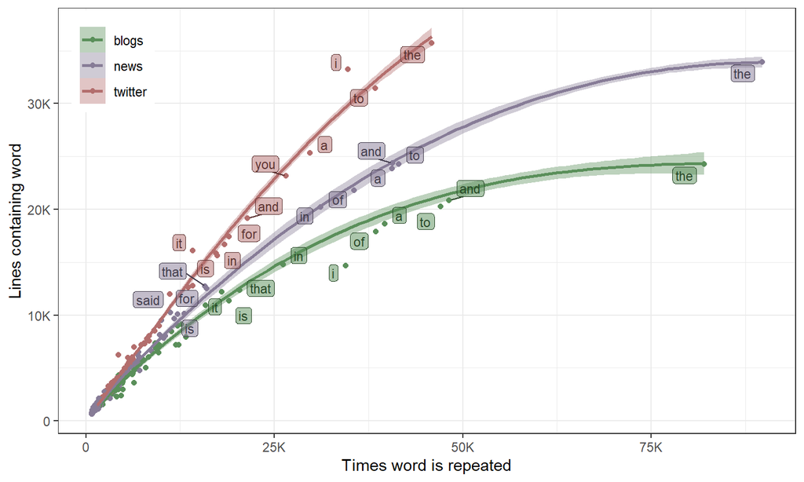

### N-Grams

I then extracted the bigrams and trigrams per text source, found their frequency and filtered so that they only included words in the top 90%.

| Type | Rank | Bigram | Frequency | Trigram | Frequency |
| --- | --- | --- | --- | --- | --- |
| blogs | 1st | of the | 8,172 | one of the | 587 |
|  | 2nd | in the | 6,742 | a lot of | 522 |
|  | 3rd | to the | 3,874 | the end of | 314 |
|  | 4th | on the | 3,317 | to be a | 313 |
|  | 5th | to be | 3,078 | some of the | 301 |
| news | 1st | of the | 8,456 | one of the | 643 |
|  | 2nd | in the | 8,230 | a lot of | 518 |
|  | 3rd | to the | 3,894 | as well as | 306 |
|  | 4th | on the | 3,200 | the end of | 289 |
|  | 5th | for the | 3,079 | according to the | 263 |
| twitter | 1st | in the | 3,885 | thanks for the | 1,184 |
|  | 2nd | for the | 3,716 | thank you for | 454 |
|  | 3rd | of the | 2,806 | looking forward to | 441 |
|  | 4th | on the | 2,307 | i love you | 427 |
|  | 5th | to be | 2,249 | for the follow | 402 |

### Model Strategy

The next step is to create a model that will be accessed through a Shiny App. The model will:

- Predict the next word via n-gram tokenisation.
- Reduce words used to speed up processing.
- Attempt to predict unseen sequences of words.

**Thank you for grading my submission!**